# Computational Homework #4

**Due by midnight on Monday October 11, 2021. Submit on Canvas**. Answer all of the following problems. These problems should be completed in this notebook (using the R kernel). Computational questions may require code, plots, analysis, interpretation, etc. Working in small groups is allowed, but it is important that you make an effort to master the material and hand in your own work.

### Problem #1

#### Run a simulation to build evidence for or against the following claim: The simple linear regression line fitted to the points in the scatter plot of $Y$ versus $\widehat{Y}$ has zero intercept and a unit slope.

To do this, simulate some data with a known slope and intercept parameters, then fit an SLR model to the data, and plot the response vs the fitted values.

```r
set.seed(1111)

x = rnorm(275, 1, 3)
z = rnorm(275, -1, 2)
c = rnorm(275, 0, 1)

y = (x + z - c)

mod = lm(y ~ c)
summary(mod)
```

```
##
## Call:
## lm(formula = y ~ c)
##
## Residuals:
##      Min       1Q   Median       3Q      Max
## -11.0102  -2.5074  -0.2737   2.3648   9.5096
##
## Coefficients:
##             Estimate Std. Error t value Pr(>|t|)
## (Intercept)   0.4216     0.2260   1.866  0.06317 .
## c            -0.6864     0.2271  -3.023  0.00274 **
## ---
## Signif. codes:  0 '***' 0.001 '**' 0.01 '*' 0.05 '.' 0.1 ' ' 1
##
## Residual standard error: 3.654 on 273 degrees of freedom
## Multiple R-squared:  0.03239,    Adjusted R-squared:  0.02885
## F-statistic: 9.139 on 1 and 273 DF,  p-value: 0.002739
```

```r
yHat = fitted.values(mod)
model = lm(y ~ yHat)
summary(model)
```

```
##
## Call:
## lm(formula = y ~ yHat)
##
## Residuals:
##      Min       1Q   Median       3Q      Max
## -11.0102  -2.5074  -0.2737   2.3648   9.5096
##
## Coefficients:
##              Estimate Std. Error t value Pr(>|t|)
## (Intercept) 6.427e-16  2.907e-01   0.000  1.00000
## yHat        1.000e+00  3.308e-01   3.023  0.00274 **
## ---
## Signif. codes:  0 '***' 0.001 '**' 0.01 '*' 0.05 '.' 0.1 ' ' 1
##
## Residual standard error: 3.654 on 273 degrees of freedom
## Multiple R-squared:  0.03239,    Adjusted R-squared:  0.02885
## F-statistic: 9.139 on 1 and 273 DF,  p-value: 0.002739
```

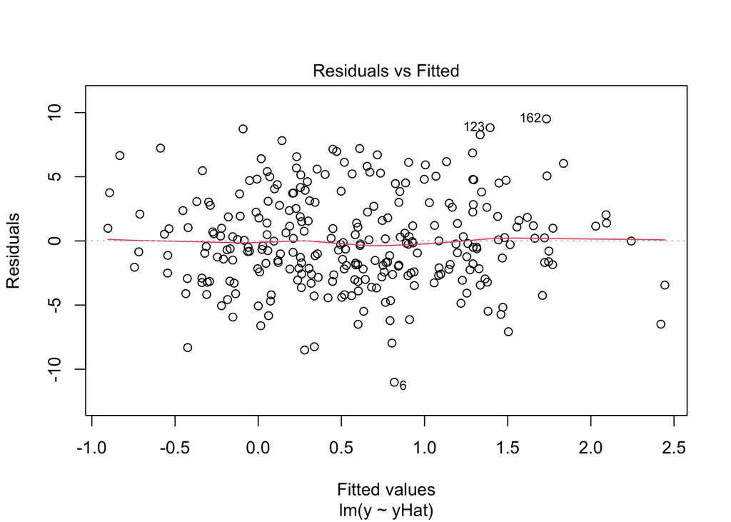

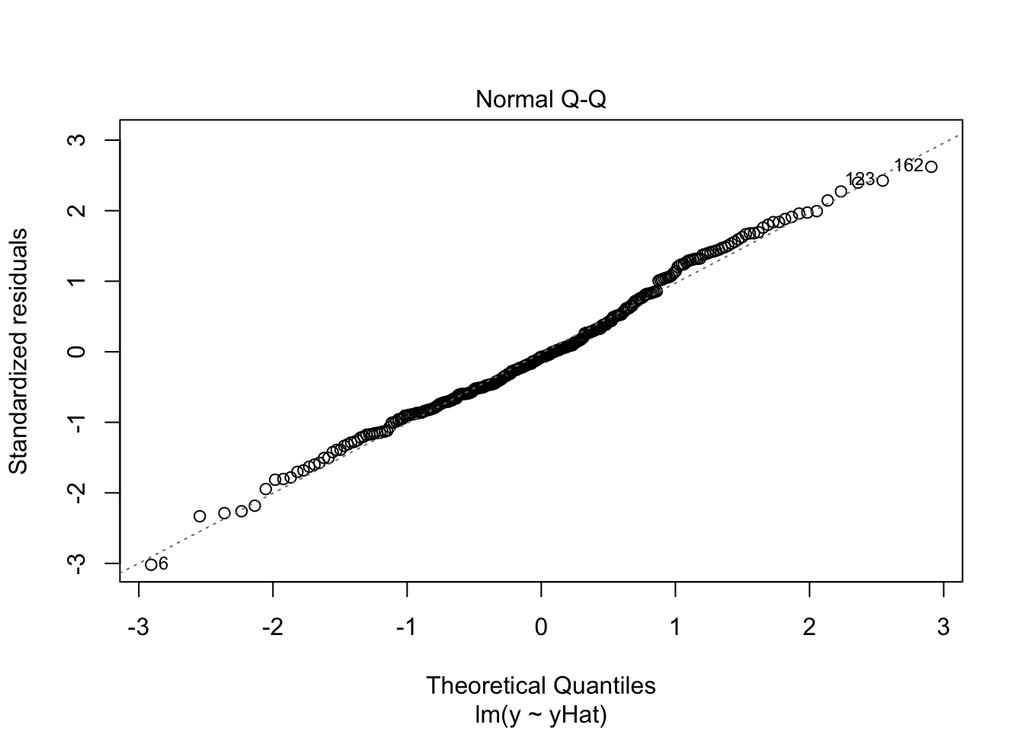

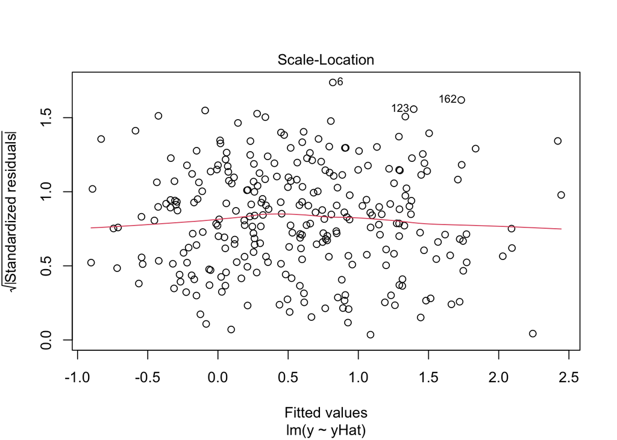

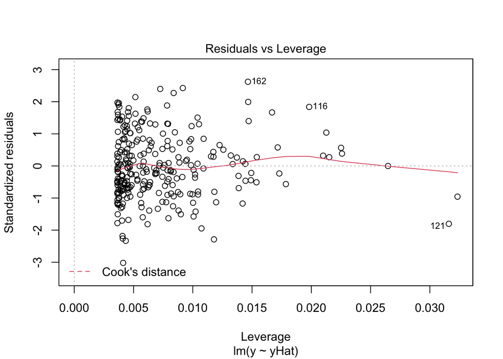

```r
plot(model)
```

```r
print("Based on the results, we can see the points in the scatter plot of (Y) Vs.(yHat) has zero intercept and a unit slope.")
```

```
## [1] "Based on the results, we can see the points in the scatter plot of (Y) Vs.(yHat) has zero intercept and a unit slope."
```